# Merging and Joining Data Sets

## Joining

“Combining datasets”

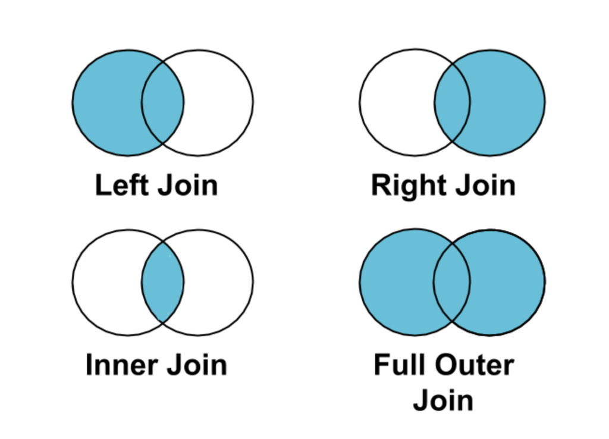

## Joining in `dplyr`

- Merging/joining data sets together - usually on key variables, usually “id”
- `?join` - see different types of joining for `dplyr`
- `inner_join(x, y)` - only rows that match for `x` and `y` are kept
- `full_join(x, y)` - all rows of `x` and `y` are kept
- `left_join(x, y)` - all rows of `x` are kept even if not merged with `y`
- `right_join(x, y)` - all rows of `y` are kept even if not merged with `x`
- `anti_join(x, y)` - all rows from `x` not in `y` keeping just columns from `x`.

## Merging: Simple Data

```r
data_As
```

```
# A tibble: 2 × 3
  State   June_vacc_rate May_vacc_rate
  <chr>            <dbl>         <dbl>
1 Alabama          0.516         0.514
2 Alaska           0.627         0.626
```

```r
data_cold
```

```
# A tibble: 3 × 2
  State   April_vacc_rate
  <chr>             <dbl>
1 Maine             0.795
2 Alaska            0.623
3 Vermont           0.82
```

## Inner Join

https://github.com/gadenbuie/tidyexplain/blob/main/images/inner-join.gif

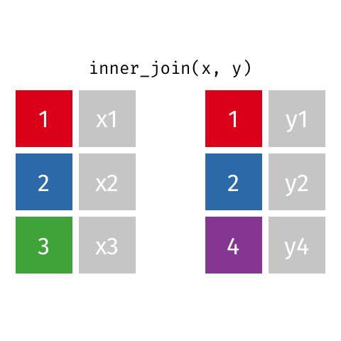

## Inner Join

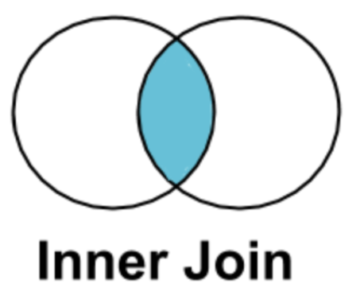

## Inner Join

```r
lj <- inner_join(data_As, data_cold)
```

```
Joining with `by = join_by(State)`
```

```r
lj
```

```
# A tibble: 1 × 4
  State  June_vacc_rate May_vacc_rate April_vacc_rate
  <chr>           <dbl>         <dbl>           <dbl>
1 Alaska          0.627         0.626           0.623
```

## Left Join

https://raw.githubusercontent.com/gadenbuie/tidyexplain/main/images/left-join.gif

## Left Join

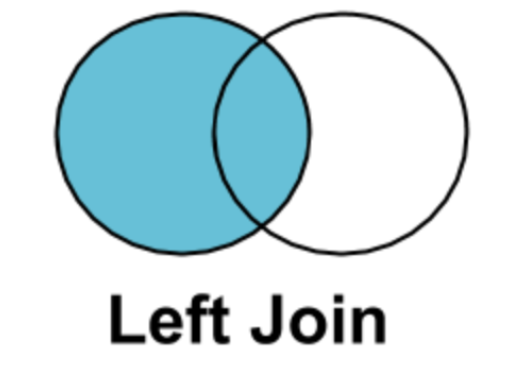

## Left Join

```r
lj <- left_join(data_As, data_cold)
```

```
Joining with `by = join_by(State)`
```

```r
lj
```

```
# A tibble: 2 × 4
  State   June_vacc_rate May_vacc_rate April_vacc_rate
  <chr>            <dbl>         <dbl>           <dbl>
1 Alabama          0.516         0.514          NA
2 Alaska           0.627         0.626           0.623
```

## Install `tidylog` package to log outputs

Numbers in parentheses indicate that these rows are not included in the result.

```r
# install.packages("tidylog")
library(tidylog)
left_join(data_As, data_cold)
```

```
Joining with `by = join_by(State)`
left_join: added one column (April_vacc_rate)
> rows only in data_As 1
> rows only in data_cold (2)
> matched rows 1
> ===
> rows total 2
```

```
# A tibble: 2 × 4
  State   June_vacc_rate May_vacc_rate April_vacc_rate
  <chr>            <dbl>         <dbl>           <dbl>
1 Alabama          0.516         0.514          NA
2 Alaska           0.627         0.626           0.623
```

## Right Join

https://raw.githubusercontent.com/gadenbuie/tidyexplain/main/images/right-join.gif

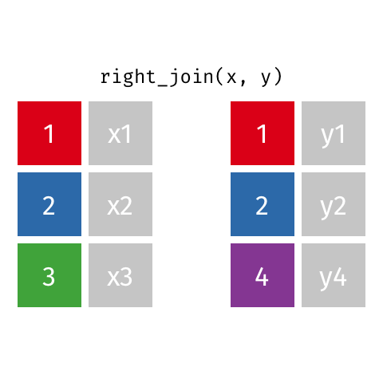

## Right Join

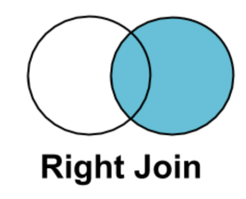

## Right Join

```r
rj <- right_join(data_As, data_cold)
```

```
Joining with `by = join_by(State)`
right_join: added one column (April_vacc_rate)
> rows only in data_As (1)
> rows only in data_cold 2
> matched rows 1
> ===
> rows total 3
```

```r
rj
```

```
# A tibble: 3 × 4
  State   June_vacc_rate May_vacc_rate April_vacc_rate
  <chr>            <dbl>         <dbl>           <dbl>
1 Alaska           0.627         0.626           0.623
2 Maine           NA            NA               0.795
3 Vermont         NA            NA               0.82
```

## Left Join: Switching arguments

```r
lj2 <- left_join(data_cold, data_As)
```

```
Joining with `by = join_by(State)`
left_join: added 2 columns (June_vacc_rate, May_vacc_rate)
> rows only in data_cold 2
> rows only in data_As (1)
> matched rows 1
> ===
> rows total 3
```

```r
lj2
```

```
# A tibble: 3 × 4
  State   April_vacc_rate June_vacc_rate May_vacc_rate
  <chr>             <dbl>          <dbl>         <dbl>
1 Maine             0.795         NA            NA
2 Alaska            0.623          0.627         0.626
3 Vermont           0.82          NA            NA
```

## Full Join

https://raw.githubusercontent.com/gadenbuie/tidyexplain/main/images/full-join.gif

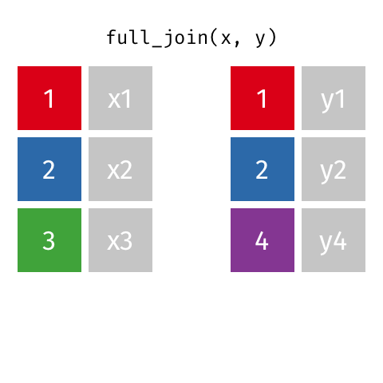

## Full Join

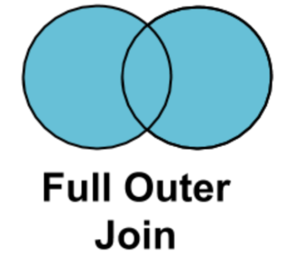

## Full Join

```r
fj <- full_join(data_As, data_cold)
```

```
Joining with `by = join_by(State)`
full_join: added one column (April_vacc_rate)
> rows only in data_As 1
> rows only in data_cold 2
> matched rows 1
> ===
> rows total 4
```

```r
fj
```

```
# A tibble: 4 × 4
  State   June_vacc_rate May_vacc_rate April_vacc_rate
  <chr>            <dbl>         <dbl>           <dbl>
1 Alabama          0.516         0.514          NA
2 Alaska           0.627         0.626           0.623
3 Maine           NA            NA               0.795
4 Vermont         NA            NA               0.82
```

## Watch out for “`includes duplicates`”

https://github.com/gadenbuie/tidyexplain/blob/main/images/left-join-extra.gif

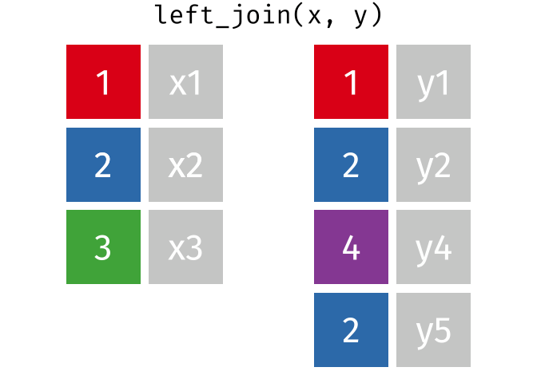

## Stop `tidylog`

```r
unloadNamespace("tidylog")
```

## GUT CHECK!

Why use `join` functions?

A. Combine different data sources

B. Connect Rmd to other files

C. Using one data source is too easy and we want our analysis ~ fancy ~

## Using the `by` argument

By default joins use the intersection of column names. If `by` is specified, it uses that.

```r
full_join(data_As, data_cold, by = "State")
```

```
# A tibble: 4 × 4
  State   June_vacc_rate May_vacc_rate April_vacc_rate
  <chr>            <dbl>         <dbl>           <dbl>
1 Alabama          0.516         0.514          NA
2 Alaska           0.627         0.626           0.623
3 Maine           NA            NA               0.795
4 Vermont         NA            NA               0.82
```

## Using the `by` argument

You can join based on multiple columns by using something like `by = c(col1, col2)`.

If the datasets have two different names for the same data, use:

```r
full_join(x, y, by = c("state" = "entity_territory"))
```

## Using “`setdiff`” (base)

We might want to determine what indexes ARE in the first dataset that AREN’T in the second:

```r
data_As
```

```
# A tibble: 2 × 3
  State   June_vacc_rate May_vacc_rate
  <chr>            <dbl>         <dbl>
1 Alabama          0.516         0.514
2 Alaska           0.627         0.626
```

```r
data_cold
```

```
# A tibble: 3 × 2
  State   April_vacc_rate
  <chr>             <dbl>
1 Maine             0.795
2 Alaska            0.623
3 Vermont           0.82
```

## Using “`setdiff`” (base)

Use `setdiff` to determine what indexes ARE in the first dataset that AREN’T in the second:

```r
A_states <- data_As |> pull(State)
cold_states <- data_cold |> pull(State)
```

```r
setdiff(A_states, cold_states)
```

```
[1] "Alabama"
```

```r
setdiff(cold_states, A_states)
```

```
[1] "Maine"   "Vermont"
```

## Using `bind_rows()` (`dplyr`)

Rows are stacked on top of each other. Works like `rbind()` from base R, but is “smarter” and looks for matching column names.

```r
rbind(data_As, data_cold)
```

```
Error in `rbind()`:
! numbers of columns of arguments do not match
```

```r
bind_rows(data_As, data_cold)
```

```
# A tibble: 5 × 4
  State   June_vacc_rate May_vacc_rate April_vacc_rate
  <chr>            <dbl>         <dbl>           <dbl>
1 Alabama          0.516         0.514          NA
2 Alaska           0.627         0.626          NA
3 Maine           NA            NA               0.795
4 Alaska          NA            NA               0.623
5 Vermont         NA            NA               0.82
```

## bind_rows vs full join

```r
full_join(data_As, data_cold)
```

```
Joining with `by = join_by(State)`
```

```
# A tibble: 4 × 4
  State   June_vacc_rate May_vacc_rate April_vacc_rate
  <chr>            <dbl>         <dbl>           <dbl>
1 Alabama          0.516         0.514          NA
2 Alaska           0.627         0.626           0.623
3 Maine           NA            NA               0.795
4 Vermont         NA            NA               0.82
```

## Other stuff: `anti_join` (`dplyr`)

[figure not shown]

[source](https://www.geeksforgeeks.org/anti-join-in-r/)

## `anti_join()`

https://raw.githubusercontent.com/gadenbuie/tidyexplain/main/images/anti-join.gif

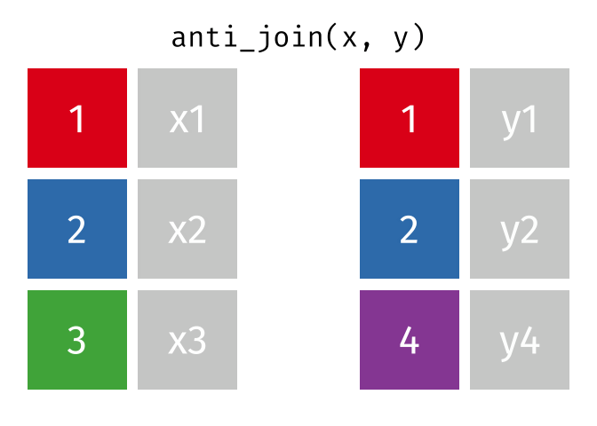

## Other stuff: `anti_join` (`dplyr`)

```r
anti_join(data_As, data_cold)
```

```
Joining with `by = join_by(State)`
```

```
# A tibble: 1 × 3
  State   June_vacc_rate May_vacc_rate
  <chr>            <dbl>         <dbl>
1 Alabama          0.516         0.514
```

## Other stuff: `anti_join` (`dplyr`)

```r
anti_join(data_cold, data_As)
```

```
Joining with `by = join_by(State)`
```

```
# A tibble: 2 × 2
  State   April_vacc_rate
  <chr>             <dbl>
1 Maine             0.795
2 Vermont           0.82
```

## Summary

- Merging/joining data sets together - assumes all column names that overlap
  - use the `by = c("a" = "b")` if they differ
- `inner_join(x, y)` - only rows that match for `x` and `y` are kept
- `full_join(x, y)` - all rows of `x` and `y` are kept
- `left_join(x, y)` - all rows of `x` are kept even if not merged with `y`
- `right_join(x, y)` - all rows of `y` are kept even if not merged with `x`
- Use the `tidylog` package for a detailed summary
- `setdiff(x, y)` shows what in `x` is missing from `y`
- `bind_rows(x, y)` appends datasets

https://sisbid.github.io/Data-Wrangling/12_Data_Merging/lab/merging-lab.Rmd

## Extra slides

## Learn more

There are lots of options for more complicated merges. Check out the documentation if you have a special use case:

https://dplyr.tidyverse.org/reference/mutate-joins.html

`?dplyr::setops` also has lots of functions for performing set operations using the rows of a data frame instead of vectors (including `intersect`, `union`, `setdiff`, etc.)

## Other stuff: `cross_join` (`dplyr`)

Cross joins match each row in x to every row in y, resulting in a data frame with `nrow(x)` * `nrow(y)` rows.

```r
cross_join(data_As, data_cold)
```

```
# A tibble: 6 × 5
  State.x June_vacc_rate May_vacc_rate State.y April_vacc_rate
  <chr>            <dbl>         <dbl> <chr>             <dbl>
1 Alabama          0.516         0.514 Maine             0.795
2 Alabama          0.516         0.514 Alaska            0.623
3 Alabama          0.516         0.514 Vermont           0.82
4 Alaska           0.627         0.626 Maine             0.795
5 Alaska           0.627         0.626 Alaska            0.623
6 Alaska           0.627         0.626 Vermont           0.82
```

## Other stuff: `nest_join` (`dplyr`)

A nest join leaves x almost unchanged, except that it adds a new column for the y dataset. Matched values are stored inside the “cell” as a tibble.

```r
nj <- nest_join(data_As, data_cold)
```

```
Joining with `by = join_by(State)`
```

```r
nj
```

```
# A tibble: 2 × 4
  State   June_vacc_rate May_vacc_rate data_cold
  <chr>            <dbl>         <dbl> <list>
1 Alabama          0.516         0.514 <tibble [0 × 1]>
2 Alaska           0.627         0.626 <tibble [1 × 1]>
```

## Other stuff: `nest_join` (`dplyr`)

```r
nj |> pull(data_cold)
```

```
[[1]]
# A tibble: 0 × 1
# ℹ 1 variable: April_vacc_rate <dbl>

[[2]]
# A tibble: 1 × 1
  April_vacc_rate
            <dbl>
1           0.623
```

## “Includes duplicates” with both datasets duplicated:

```r
data_As <- tibble(State = c("Alabama", "Alaska", "Alaska"),
                 state_bird = c("wild turkey", "willow ptarmigan", "puffin"))
data_cold <- tibble(State = c("Maine", "Alaska", "Alaska"),
                    vacc_rate = c("32.4%", "41.7%", "46.2%"),
                    month = c("April", "April", "May"))
```

## “Includes duplicates” with both datasets duplicated:

```r
full_join(data_As, data_cold)
```

```
Joining with `by = join_by(State)`
```

```
Warning in full_join(data_As, data_cold): Detected an unexpected many-to-many relationship between `x` and `y`.
ℹ Row 2 of `x` matches multiple rows in `y`.
ℹ Row 2 of `y` matches multiple rows in `x`.
ℹ If a many-to-many relationship is expected, set `relationship = "many-to-many"` to silence this warning.
```

```
# A tibble: 6 × 4
  State   state_bird       vacc_rate month
  <chr>   <chr>            <chr>     <chr>
1 Alabama wild turkey      <NA>      <NA>
2 Alaska  willow ptarmigan 41.7%     April
3 Alaska  willow ptarmigan 46.2%     May
4 Alaska  puffin           41.7%     April
5 Alaska  puffin           46.2%     May
6 Maine   <NA>             32.4%     April
```